# Interpretation of RDA results

J. Ignacio Lucas Lledó

21/4/2020

# The data

Recall the contents of the variables just imported from `2020-04-13`:

- `A` is the relative abundances of 614 amplicons in early life, and 418 amplicons late in life. Columns are amplicons $\times$ age combinations, and rows correspond to the 24 isolines with microbiome data. Only amplicons present in at least 5 isolines, and with an average relative frequency of at least 5.0e-5 are included.
- `A.log` are the log transformed relative abundances. The logarithmic transformation proved useful to reduce the skewness of abundance distributions across isolines. Amplicons the abundance of which was still too skewed were removed, leaving 434 amplicons early and 318 amplicons late in life.
- `A.pca` is the principal component analysis of `A.log`. Because it is based on only 24 observations, only 23 eigenvalues are positive, the rest being zero.
- `batch` is a vector indicating the proportion of samples from each isoline processed in the second (of two) batch. Used to account for technical variation.
- `LH` is the complete matrix of life-history traits for 29 isolines, including some for which we don’t have microbiome data.
- `LH.imp` is the object that holds the 10 imputations of the 2 missing values in variable `ActuarialB`.

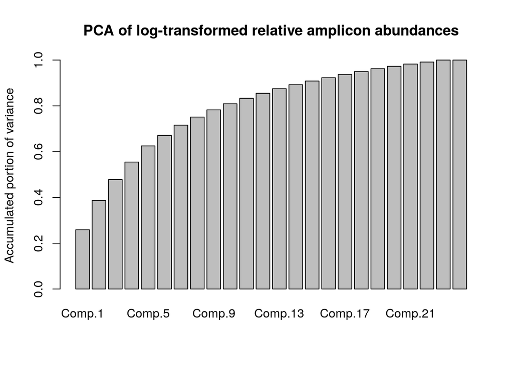

```r
barplot(cumsum(eigenvals(A.pca))[1:24] / sum(eigenvals(A.pca)),
        main = 'PCA of log-transformed relative amplicon abundances',
        ylab = 'Accumulated portion of variance')
```

```r
# LH.all is a list of LH matrices with imputed values.
LH.all <- complete(LH.imp, action='all')
validIsolines  <- row.names(A)
validVariables <- c('CSearly', 'CSSlope', 'EarlyRS', 'Rsen', 'AvLF', 'ActuarialB')
LH.all <- lapply(LH.all, function(x, f1=validIsolines, f2=validVariables) x[f1, f2])
```

# Global test

The RDA analysis could take up to 22 components from the `A.pca`, because I also include the batch effect. All together, 23: one less than the number of observations. However, when testing for significance of the model, it seems that I need some degrees of freedom, and the permutation test does not produce a *p* value unless there are less than 22 components. In any case, the `rda()` function will only produces 6 eigenvectors, because there are 6 variables left in the matrix of life-history traits.

So, the question is what components of the variation in amplicon abundances carry any correlation signal with life-history variables. Recall that PCA components are ordered by the amount of variance they represent, which does not have to coincide with the amount of correlation. Thus, any component could be correlated with life-history traits.

If we include all the components together, and test the global significance of the model, the result is quite negative:

```r
RDA21 <- lapply(LH.all, function(lh) rda(lh ~ . + Condition(batch),
                                         data = as.data.frame(A.pca$scores[,1:21])))
RDA21.anova <- lapply(RDA21, anova)
# This is the result for the first imputation:
RDA21.anova[[1]]
```

```
## Permutation test for rda under reduced model
## Permutation: free
## Number of permutations: 999
##
## Model: rda(formula = lh ~ Comp.1 + Comp.2 + Comp.3 + Comp.4 + Comp.5 + Comp.6 + Comp.7 + Comp.8 + Comp.9 + Comp.10 + Comp.11 + Comp.12 + Comp.13 + Comp.14 + Comp.15 + Comp.16 + Comp.17 + Comp.18 + Comp.19 + Comp.20 + Comp.21 + Condition(batch), data = as.data.frame(A.pca$scores[, 1:21]))
##          Df Variance      F Pr(>F)
## Model    21   5.2868 1.1934  0.487
## Residual  1   0.2110
```

```r
# And this, all the p values from all imputations.
sapply(RDA21.anova, function(x) x$'Pr(>F)'[1])
```

```
##     1     2     3     4     5     6     7     8     9    10
## 0.487 0.472 0.471 0.499 0.482 0.472 0.492 0.474 0.478 0.461
```

The *p* values from all imputed data sets are non-significant. We should conclude that there is no significant correlation (that we can detect) between gut microbiome composition and life-history traits. Blanchet, Legendre, and Borcard (2008) warn any results we get beyond this point are bound to be false positives.

# “Post-truth” analysis

Well, but let’s not stop the fun here. Keeping the warning in mind, let’s see what a positive result would look like. The function `ordiR2step()` in the `vegan` package sequentially adds terms to a model, as long as they are significant, and it seems to implement the recommendations by Blanchet, Legendre, and Borcard (2008) to avoid false positives. However, that function is not supposed to be valid for partial ordinations, like ours, because the adjusted $R^2$ “cannot be calculated”. For some reason, both `ordiR2step()` and `RsquareAdj()` run without a warning on our rda objects. In any case, I will use the alternative, `ordistep()`, which can make both forward and backward steps.

```r
# Starting point: a model without abundance components.
RDA0 <- lapply(LH.all, function(lh) rda(lh ~ Condition(batch),
                                        data = as.data.frame(A.pca$scores[,1:21])))
RDA  <- lapply(RDA0, function(x) ordistep(x, RDA21[[1]], Pin=0.1, Pout=0.15, steps=100, trace=FALSE))
```

```r
lapply(RDA, function(x) x$terms[[3]])
```

```
## $`1`
## Condition(batch) + Comp.14 + Comp.7 + Comp.6 + Comp.21 + Comp.1
##
## $`2`
## Condition(batch) + Comp.14 + Comp.7 + Comp.21 + Comp.1 + Comp.6
##
## $`3`
## Condition(batch) + Comp.14 + Comp.6 + Comp.7 + Comp.21 + Comp.1
##
## $`4`
## Condition(batch) + Comp.14 + Comp.7
##
## $`5`
## Condition(batch) + Comp.14 + Comp.7 + Comp.21 + Comp.6 + Comp.1
##
## $`6`
## Condition(batch) + Comp.14 + Comp.7 + Comp.21 + Comp.6
##
## $`7`
## Condition(batch) + Comp.14 + Comp.1 + Comp.21 + Comp.6 + Comp.7
##
## $`8`
## Condition(batch) + Comp.14 + Comp.1 + Comp.6 + Comp.21 + Comp.7
##
## $`9`
## Condition(batch) + Comp.14
##
## $`10`
## Condition(batch) + Comp.14 + Comp.7 + Comp.6 + Comp.21
```

The different imputations produced different models. All them include component 14. And components 1, 6, 7 and 21 all appear more than once. I would build two models, based on this information: the most conservative one with only component 14, and the most optimistic with all 5 components.

```r
RDA1 <- lapply(LH.all, function(lh) rda(lh ~ Comp.14 + Condition(batch),
                                        data = as.data.frame(A.pca$scores[,1:21])))
RDA5 <- lapply(LH.all, function(lh) rda(lh ~ Comp.14 + Comp.6 + Comp.7 + Comp.1 + Comp.21 + Condition(batch),
                                        data = as.data.frame(A.pca$scores[,1:21])))
```

# The minimum model: Component 14

If I understood well, when using only one predictor (`Comp.14` in `RDA1`) in redundancy analysis, we are looking for the direction in the space of the response variables that is most correlated with that predictor. A single eigenvalue is produced, that in our case is (on average across imputations): 0.8016242, and represents about 14.5350286 % of the variance in life-history traits.

It seems to me that using only one component greatly facilitates the interpretation, even though I’m not sure we can call this *multivariate* any more. It is just a series of simple linear regressions of 6 response variables against the same independent variable. Not very sofisticated, eh?

Anyways, how is this component related to life-history traits? Below I average the “species” scores of the 10 imputations in `RDA1`. Recall that in `vegan` the matrix of response variables typically represent species abundances.

```r
# Just discovered the very useful function Reduce().
Reduce('+', lapply(RDA1, function(x) scores(x, choices=1, display='sp'))) / 10
```

```
##                  RDA1
## CSearly     0.7463786
## CSSlope    -0.7527195
## EarlyRS     0.3030473
## Rsen        0.5725429
## AvLF        0.2053075
## ActuarialB  0.1376242
## attr(,"const")
## [1] 3.384403
```

We can look at the amount of variance in each life-history variable explained by component 14 of the amplicon abundances:

```r
Reduce('+', lapply(RDA1, goodness)) / 10
```

```
##                  RDA1
## CSearly    0.30450999
## CSSlope    0.29713335
## EarlyRS    0.04472614
## Rsen       0.21526148
## AvLF       0.02052536
## ActuarialB 0.01017376
```

Keeping in mind that these may be overestimates, it is interesting to see that gut microbiome seems to affect climbing speed and reproductive senescence much more than early reproductive success or life span.

We cannot see a biplot, because it’s univariate at this point.

# Taxonomy

Once we know how much component 14 affects life-history traits, it’s time to turn our attention to the meaning of that component. This is a histogram of its loadings on the several amplicons:

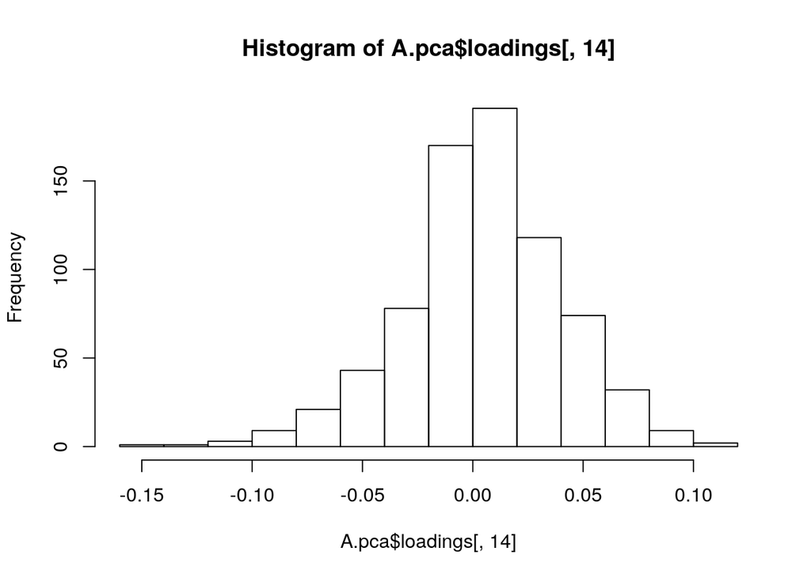

```r
hist(A.pca$loadings[,14])
```

The contribution of most amplicons to component 14 is small. These are the 21 amplicons with the most extreme loadings in component 14:

```r
A14max <- A.pca$loadings[order(abs(A.pca$loadings[,14]), decreasing=TRUE)[1:21], 14, drop=FALSE]
A14max
```

```
##            Comp.14
## EA0302 -0.15507405
## LA0109 -0.12641733
## LA0135  0.11139620
## EA0241 -0.10568951
## EA0271 -0.10326338
## EA0359 -0.10247138
## EA0801  0.10154093
## LA0251  0.09898693
## EA0274 -0.09628354
## EA0464  0.09494909
## LA0277  0.09322867
## LA0654 -0.09213539
## EA0314 -0.09074934
## EA0053 -0.08884051
## LA0193  0.08838394
## LA0236  0.08697244
## EA1164  0.08650080
## EA0149 -0.08611439
## LA0118 -0.08584534
## EA0127 -0.08584283
## EA0081 -0.08552811
```

They include both early and late life abundances. Let’s add some information.

```r
A14max <- data.frame(Loading14 = A14max[,1])
A14max$age <- factor('Early', levels=c('Early', 'Late'))
A14max[startsWith(row.names(A14max), 'L'), 'age'] <- 'Late'
A14max$amplicon <- substr(row.names(A14max), 2, 6)
A14max$Phylum <- taxa[A14max$amplicon, 2]
A14max$Class  <- taxa[A14max$amplicon, 3]
A14max$Order  <- taxa[A14max$amplicon, 4]
A14max$Family <- taxa[A14max$amplicon, 5]
A14max$Genus  <- taxa[A14max$amplicon, 6]
A14max$Species <- taxa[A14max$amplicon, 7]

table(A14max$age, A14max$Genus)
```

```
##
##         Acetobacter Lactobacillus Lawsonella Pseudomonas Ralstonia
##   Early           8             0          1           1         3
##   Late            5             1          0           0         2
```

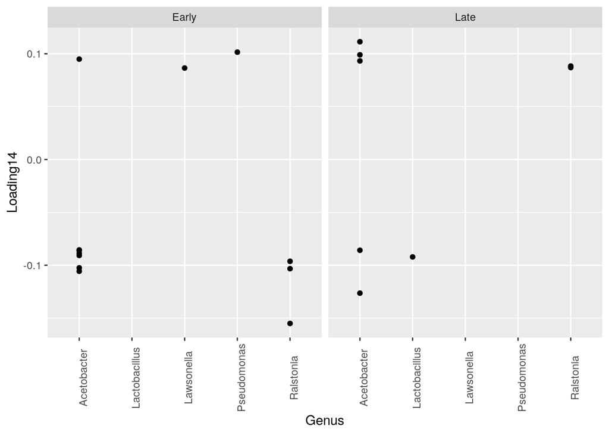

```r
ggplot(data = A14max, mapping = aes(x = Genus, y = Loading14)) +
  geom_point() + facet_wrap(~age) + theme(axis.text.x = element_text(angle = 90))
```

Are these amplicons really affecting life-history traits? Let’s run the RDA analysis directly with them, the 21 amplicons that most heavily load on component 14, which is the one most likely to affect life-history traits.

```r
RDAmax <- lapply(LH.all, function(lh) rda(lh ~ . + Condition(batch),
                                          data = A.log[, row.names(A14max)]))
anova(RDAmax[[1]])
```

```
## Permutation test for rda under reduced model
## Permutation: free
## Number of permutations: 999
##
## Model: rda(formula = lh ~ EA0302 + LA0109 + LA0135 + EA0241 + EA0271 + EA0359 + EA0801 + LA0251 + EA0274 + EA0464 + LA0277 + LA0654 + EA0314 + EA0053 + LA0193 + LA0236 + EA1164 + EA0149 + LA0118 + EA0127 + EA0081 + Condition(batch), data = A.log[, row.names(A14max)])
##          Df Variance      F Pr(>F)
## Model    21   5.0708 0.5654  0.885
## Residual  1   0.4270
```

```r
RDA0 <- lapply(LH.all, function(lh) rda(lh ~ Condition(batch),
                                           data = A.log[, row.names(A14max)]))
RDA.amp <- lapply(RDA0, function(x) ordistep(x, RDAmax[[1]], Pin=0.1, Pout=0.15, steps=100, trace=FALSE))
```

```r
lapply(RDA.amp, function(x) x$terms[[3]])
```

```
## $`1`
## Condition(batch)
##
## $`2`
## Condition(batch)
##
## $`3`
## Condition(batch)
##
## $`4`
## Condition(batch)
##
## $`5`
## Condition(batch)
##
## $`6`
## Condition(batch)
##
## $`7`
## Condition(batch)
##
## $`8`
## Condition(batch)
##
## $`9`
## Condition(batch)
##
## $`10`
## Condition(batch)
```

The answer is negative.

Blanchet, F.G., P. Legendre, and D. Borcard. 2008. “Forward Selection of Explanatory Variables.” *Ecology* 89 (9): 2623–32. doi:10.1890/07-0986.1.